# Ayudantía 4. Selection models - Heckman

Profesor: Tomás Rau Ayudantes: Valentina Andrade y Nicolás Valle

12 de abril de 2024

Abstract

En este ejercicio simularemos datos de modo que conoceremos el GDP, y cómo están seleccionados los datos. Lo que hacemos es verificar cómo afecta la selección a la estimación, y como la propuesta de **Heckman** permite lidiar con este problema.

## Set del problema

Descripción de los datos:

- Seleccionar aleatoriamente 10,000 observaciones
- educ uniforme entre [0,16]
- age uniforme entre [18,64]
- wearnl = 4.49 + 0.08 * educ + 0.012 * age + $\varepsilon$

**¿Qué haremos?**

Generaremos datos faltantes para wearnl extraídos de z de la normal estándar [0,1].

$$d^* = -1.5 + 0.15 \times educ + 0.01 \times age + 0.15 \times z + v$$

$$\text{wearnl se define como:}
\begin{cases}
\text{falta si } d^* \leq 0 \\
\text{informado si } d^* > 0
\end{cases}$$

$$\text{wearnl\_all} = \text{wearnl con observaciones no faltantes}$$

## Set de los datos

```r
set.seed(123456)

N = 10000
educ = sample(1:16, N, replace = TRUE)
age  = sample(18:64, N, replace = TRUE)

covmat = matrix(c(.46^2, .25*.46, .25*.46, 1), ncol = 2)
errors = mvtnorm::rmvnorm(N, sigma = covmat)
z = rnorm(N)
e = errors[, 1]
v = errors[, 2]

wearnl = 4.49 + .08 * educ + .012 * age + e

d_star = -1.5 + 0.15 * educ + 0.01 * age + 0.15 * z + v

observed_index  = d_star > 0

d = data.frame(wearnl, educ, age, z, observed_index)
```

Ahora miremos el OLS observado y completo

```r
# lm basado en datos completos
lm_all = lm(wearnl ~ educ + age, data=d)

# lm basado en datos observados
lm_obs = lm(wearnl ~ educ + age, data=d[observed_index,])

tab_model(lm_all, lm_obs,
          dv.labels = c("LM all", "LM obs"),
          p.style = "stars",
          collapse.ci = TRUE)
```

LM all

LM obs

Predictors

Estimates

Estimates

(Intercept)

4.47 ***  
(4.44 – 4.50)

4.67 ***  
(4.62 – 4.72)

educ

0.08 ***  
(0.08 – 0.08)

0.07 ***  
(0.07 – 0.07)

age

0.01 ***  
(0.01 – 0.01)

0.01 ***  
(0.01 – 0.01)

Observations

10000

5520

R<sup>2</sup> / R<sup>2</sup> adjusted

0.433 / 0.433

0.337 / 0.337

# Selection model by Heckman

## Two way step

- Paso 1: Realiza un modelo probit respecto a si el individuo es observado o no, con el fin de calcular la [razón de Mills inversa](https://es.wikipedia.org/wiki/Raz%C3%B3n_de_Mills#Raz%C3%B3n_de_Mills_inversa), o ‘peligro de no selección’ (hazard rate).
- Paso 2: Estimar el modelo lineal estándar, incorporando la selección.

### Paso 1: Modelo Probit

Se ajusta un modelo probit donde la variable dependiente es observed_index, una variable indicadora de si la observación de salario está presente o no. Los predictores son educ, age, y una variable adicional z, que podría representar otras características individuales o contextuales que afectan la probabilidad de observación. El probit se usa para modelar la probabilidad de que observed_index sea 1 (es decir, que el salario sea observado).

```r
probit = glm(observed_index ~ educ + age + z,
             data   = d,
             family = binomial(link = 'probit'))

summary(probit)
```

```
##
## Call:
## glm(formula = observed_index ~ educ + age + z, family = binomial(link = "probit"),
##     data = d)
##
## Deviance Residuals:
##     Min       1Q   Median       3Q      Max
## -2.4674  -0.9062   0.4628   0.8800   2.2674
##
## Coefficients:
##              Estimate Std. Error z value Pr(>|z|)
## (Intercept) -1.519248   0.052819 -28.763   <2e-16 ***
## educ         0.150027   0.003220  46.588   <2e-16 ***
## age          0.010072   0.001015   9.926   <2e-16 ***
## z            0.159292   0.013889  11.469   <2e-16 ***
## ---
## Signif. codes:  0 '***' 0.001 '**' 0.01 '*' 0.05 '.' 0.1 ' ' 1
##
## (Dispersion parameter for binomial family taken to be 1)
##
##     Null deviance: 13755  on 9999  degrees of freedom
## Residual deviance: 11119  on 9996  degrees of freedom
## AIC: 11127
##
## Number of Fisher Scoring iterations: 4
```

```r
# ¿Cómo calcular el inverse mills ratio? Mira este link:
# http://www.stata.com/support/faqs/statistics/inverse-mills-ratio/
probit_lp = predict(probit)
mills0 = dnorm(probit_lp)/pnorm(probit_lp)

summary(mills0)
```

```
##    Min. 1st Qu.  Median    Mean 3rd Qu.    Max.
## 0.07588 0.38632 0.70027 0.75664 1.09246 1.96602
```

```r
# Otra forma de hacerlo:
# probit_lp = -predict(probit)
# imr = dnorm(probit_lp)/(1-pnorm(probit_lp))
imr = mills0[observed_index]

summary(imr)
```

```
##    Min. 1st Qu.  Median    Mean 3rd Qu.    Max.
## 0.07588 0.28739 0.48466 0.57015 0.77617 1.87858
```

Después de estimar el modelo probit, calculas el Inverse Mills Ratio (IMR) para cada observación. El IMR se obtiene dividiendo la densidad de la distribución normal estándar (dnorm(probit_lp)) por la función de distribución acumulativa (pnorm(probit_lp)), donde probit_lp son los valores predichos del modelo probit. Este ratio es crucial para el segundo paso del modelo de Heckman, ya que ajusta las estimaciones por el sesgo de selección.

¿Cómo calcular el inverse mills ratio? Mira este [link](http://www.stata.com/support/faqs/statistics/inverse-mills-ratio/)

```r
probit_lp = predict(probit)
mills0 = dnorm(probit_lp)/pnorm(probit_lp)

summary(mills0)
```

```
##    Min. 1st Qu.  Median    Mean 3rd Qu.    Max.
## 0.07588 0.38632 0.70027 0.75664 1.09246 1.96602
```

```r
# Otra forma de hacerlo:
# probit_lp = -predict(probit)
# imr = dnorm(probit_lp)/(1-pnorm(probit_lp))
imr = mills0[observed_index]

summary(imr)
```

```
##    Min. 1st Qu.  Median    Mean 3rd Qu.    Max.
## 0.07588 0.28739 0.48466 0.57015 0.77617 1.87858
```

Observemos la distribución del Inverse Mills Ratio en la muestra:

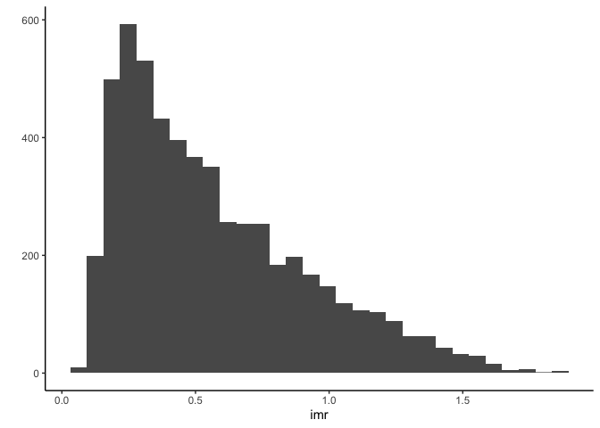

```r
ggplot2::qplot(imr, geom = 'histogram')
```

Dado que el IMR ajusta por el riesgo de selección, entender su distribución puede darte pistas sobre cuán generalizado está el problema de selección en tus datos. Por ejemplo, una distribución del IMR concentrada cerca de cero sugiere que el riesgo de sesgo de selección es bajo para la mayoría de las observaciones, mientras que una distribución más dispersa o sesgada podría indicar un riesgo variado y potencialmente más significativo de sesgo de selección a través de la muestra.

#### Interpretación:

- **Modelo Probit**: Los coeficientes del modelo probit te dicen cómo las variables `educ`, `age`, y `z` afectan la probabilidad de que una observación sea incluida (es decir, si el salario se reporta o no). Un coeficiente positivo indica que a medida que el predictor aumenta, también lo hace la probabilidad de observación.
- **IMR**: El IMR ajusta las estimaciones de la *segunda etapa* para el sesgo de selección. Observaciones con un IMR alto y estadísticamente significativo indican un mayor riesgo de selección, y este factor se incorpora en el modelo de resultado para corregir el sesgo asociado con las observaciones no aleatorias.

### Paso 2: Estimación mediante Regresión Lineal

Estimamos el modelo de regresión estándar utilizando la razón de Mills inversa como covariable

```r
lm_select = lm(wearnl ~ educ + age + imr, data = d[observed_index, ])

summary(lm_select)
```

```
##
## Call:
## lm(formula = wearnl ~ educ + age + imr, data = d[observed_index,
##     ])
##
## Residuals:
##      Min       1Q   Median       3Q      Max
## -1.75994 -0.30293 -0.00186  0.31049  1.48179
##
## Coefficients:
##              Estimate Std. Error t value Pr(>|t|)
## (Intercept) 4.5159161  0.1063144  42.477   <2e-16 ***
## educ        0.0782580  0.0052989  14.769   <2e-16 ***
## age         0.0119700  0.0005564  21.513   <2e-16 ***
## imr         0.0955209  0.0633557   1.508    0.132
## ---
## Signif. codes:  0 '***' 0.001 '**' 0.01 '*' 0.05 '.' 0.1 ' ' 1
##
## Residual standard error: 0.4506 on 5516 degrees of freedom
## Multiple R-squared:  0.3377, Adjusted R-squared:  0.3373
## F-statistic: 937.4 on 3 and 5516 DF,  p-value: < 2.2e-16
```

También lo podemos hacer con el paquete sampleSelection directamente.

```r
selection_2step = selection(observed_index ~ educ + age + z, wearnl ~ educ + age,
                            method = '2step')

summary(selection_2step)
```

```
## --------------------------------------------
## Tobit 2 model (sample selection model)
## 2-step Heckman / heckit estimation
## 10000 observations (4480 censored and 5520 observed)
## 10 free parameters (df = 9991)
## Probit selection equation:
##              Estimate Std. Error t value Pr(>|t|)
## (Intercept) -1.519248   0.052725 -28.815   <2e-16 ***
## educ         0.150027   0.003221  46.577   <2e-16 ***
## age          0.010072   0.001014   9.934   <2e-16 ***
## z            0.159292   0.013937  11.430   <2e-16 ***
## Outcome equation:
##              Estimate Std. Error t value Pr(>|t|)
## (Intercept) 4.5159161  0.1066914   42.33   <2e-16 ***
## educ        0.0782580  0.0053181   14.71   <2e-16 ***
## age         0.0119700  0.0005592   21.41   <2e-16 ***
## Multiple R-Squared:0.3377,   Adjusted R-Squared:0.3373
##    Error terms:
##               Estimate Std. Error t value Pr(>|t|)
## invMillsRatio  0.09552    0.06354   1.503    0.133
## sigma          0.45550         NA      NA       NA
## rho            0.20970         NA      NA       NA
## --------------------------------------------
```

```r
coef(lm_select)['imr'] / summary(lm_select)$sigma
```

```
##       imr
## 0.2119813
```

```r
coef(lm_select)['imr'] / summary(selection_2step)$estimate['sigma', 'Estimate']
```

```
##       imr
## 0.2097041
```

# Máxima Verosimilitud

La siguiente función de verosimilitud toma argumentos de la siguiente manera:

- **par**: los coeficientes de regresión relacionados con los dos modelos, el error estándar residual
- **sigma** y rho para la estimación de correlación
- **X**: matriz de modelo de datos observados para el modelo de regresión lineal
- **Z**: matriz de modelo de datos completos para el modelo probit
- **y**: la variable objetivo
- **observed_index**: un índice que denota si se observa el outcome

```r
select_ll <- function(par, X, Z, y, observed_index) {
  gamma     = par[1:4]
  lp_probit = Z %*% gamma

  beta  = par[5:7]
  lp_lm = X %*% beta

  sigma = par[8]
  rho   = par[9]

  ll = sum(log(1-pnorm(lp_probit[!observed_index]))) +
    - log(sigma) +
    sum(dnorm(y, mean = lp_lm, sd = sigma, log = TRUE)) +
    sum(
      pnorm((lp_probit[observed_index] + rho/sigma * (y-lp_lm)) / sqrt(1-rho^2),
            log.p = TRUE)
    )

  -ll
}
```

```r
X = model.matrix(lm_select)
Z = model.matrix(probit)

# valores iniciales
init = c(coef(probit), coef(lm_select)[-4],  1, 0)
```

Estimar mediante optim. Sin límites para sigma y rho recibirás advertencias, pero funciona de todos modos.

```r
fit_unbounded = optim(
  init,
  select_ll,
  X = X[, -4],
  Z = Z,
  y = wearnl[observed_index],
  observed_index = observed_index,
  method  = 'BFGS',
  control = list(maxit = 1000, reltol = 1e-15),
  hessian = T
)
```

### Comparación

```r
selection_ml = selection(observed_index ~ educ + age + z, wearnl ~ educ + age,
                         method = 'ml')
# summary(selection_ml)
```

Ahora comparamos los resultados de los diferentes enfoques de estimación.

| model | par | sampselpack_ml | unbounded_ml | explicit_twostep | sampselpack_2step |
| --- | --- | --- | --- | --- | --- |
| probit | (Intercept) | -1.52026540 | -1.5205913 | -1.5192475 | -1.5192475 |
| probit | educ | 0.15020205 | 0.1502068 | 0.1500272 | 0.1500272 |
| probit | age | 0.01006608 | 0.0100724 | 0.0100722 | 0.0100722 |
| probit | z | 0.15747033 | 0.1575079 | 0.1592921 | 0.1592922 |
| lm | (Intercept) | 4.47798502 | 4.4795384 | 4.5159161 | 4.5159161 |
| lm | educ | 0.08012367 | 0.0800468 | 0.0782580 | 0.0782580 |
| lm | age | 0.01209129 | 0.0120862 | 0.0119700 | 0.0119700 |
| lm | sigma | 0.45820605 | 0.4580527 | 0.4506099 | 0.4555030 |
| ambos | rho | 0.25945397 | 0.2574998 | 0.2119813 | 0.2097041 |

| model | par | sampselpack_ml | unbounded_ml | explicit_twostep | sampselpack_2step |
| --- | --- | --- | --- | --- | --- |
| probit | (Intercept) | 0.0526778 | 0.0526785 | 0.0528190 | 0.0527249 |
| probit | educ | 0.0032200 | 0.0032200 | 0.0032203 | 0.0032211 |
| probit | age | 0.0010129 | 0.0010130 | 0.0010148 | 0.0010139 |
| probit | z | 0.0139664 | 0.0139654 | 0.0138894 | 0.0139368 |
| lm | (Intercept) | 0.0900236 | 0.0899901 | 0.1063144 | 0.1066914 |
| lm | educ | 0.0044999 | 0.0045000 | 0.0052989 | 0.0053181 |
| lm | age | 0.0005302 | 0.0005296 | 0.0005564 | 0.0005592 |
| lm | sigma | 0.0081316 | 0.0080861 | NA | NA |
| ambos | rho | 0.1116601 | 0.1117715 | NA | NA |

## Fuente

Código original disponible en https://github.com/m-clark/Miscellaneous-R-Code/blob/master/ModelFitting/heckman_selection.R

[output not shown]